# Contents:

- Quick start
- Mapping Functions

### Code Examples:

- Context Generation on dummy data
  - Creating Cotext Object
- Causality Discovery
- Database Connections
- Distance Function
- Clustering Context
- Pipelines
- Simulators
  - Simulator stream
  - Simulator using pandas DataFrame
- Interpretation
- Causality Discovery Efficiency

## The API Documentation can be found [here](https://pd-m-context.vercel.app/index_old.html)

# Getting Started with Context

```python
from PdmContext.ContextGeneration import ContextGenerator
from PdmContext.utils.structure import Context
```

# Quick start

**Context** is used to encapsulate all available multimodal information towards better Anomaly Detection solutions.

Essentially Context represents the available data existing in a time window (**context_horizon**), mapped from multimodal representation to multivariate time-series (**CD**), and their relationships (**CR**), where the relationships are extracted using **causal discovery** between the time-series of CD.

[figure not shown]

.

```
pip install PdMContext
```

## Intantiating a context generator:

For Intantiation we need to pass:

- **target**: string representing the name of target source.
- **context_horizon**: the length of time window of available used to build context
- **Causality_function**: a function that implements a causality discovery method (look at Causality Discovery )
- **mapping_functions**: a dictionary of the available types of monitored data sources and their corresponding mapper (look at Mapping Function ).

```
con_gen=ContextGenerator(target="anomaly scores", context_horizon="8 hours",Causality_function,mapping_functions)
```

To feed a new sample from a data source to context we need (e.g. the temperature measured from Machine_A):

- **timestamp**: timestamp representing the time when the sample was collected (using pandas timestamps).
- **source**: A string which annotate the name of the source the sample derives.
- **name**: A string which represent the name of the time series related to the sample.
- **type**: This annotates the type (or the nature) of the sample (the type has to be one of the keys from **mapping_functions** dictionary)

```
con_gen.collect_data(timestamp=t1, source="Machine_A", name="config", type="univariate")
```

Passing a sample from **target** source trigers the creation of new context.

```
context=con_gen.collect_data(timestamp=t1, source="Machine_A", name="anomaly scores", type="univariate")
```

**PdmContext.utils.structure.Context** is used to represent such a context.

### Mapping Functions

Data sources can be any time series (producing information in time) of events, continuous values, images etc.

To formulate context from the available data sources we have to define mapping functions:

**mapping_functions**: A dictionary where the keys are the name of the different types of data sources and the value are python mapping classes, that handle to transform a time window of values observed from particular source (e.g. the events observed from a particular data source) and handles to transform them in a time series of the same length as a **target** one (the target is usually the anomaly scores).

For example, the default mapping_function used by the library is:

```
mapping_functions = {
    "Univariate":map_univariate_to_continuous(), # represent continuous sources
    "isolated": map_isolated_to_continuous(), # represent sources of events with instant impact
    "configuration": map_configuration_to_continuous(), # represent sources of events with constant impact
    "categorical":map_categorical_to_continuous() # represent sources of catigorical values
}
```

The values are classes from **PdmContext.utils.mapping_functions** and have the following form:

```
class map_name:

    def __init__(self):
        # possible code
        pass
    def map(self,target_series, occurrences,name):
        """

        target_series: the time series which will be used as guide to build a continuous representation for the particular type.
        occurrences: time series of observe value to be mapped
        name: the name of the time series to be mapped

        Both target series and occurrences has values in form of (sample, timestamp) where the sample contain the value (any data type).

        return the resulting vectors (usually just one vector) and names from mapping occurrences to time series format.
        """
    # possible methods
```

The way they transom a different sources in time series data can be seen in the following example:

- **target** : Detector score
- **isolated**: isolated event
- **configuration**: speed change
- **Univariate**: temperature, some_KPI

[figure not shown]

.

### More details regarding the default mapping_functions:

#### Continuous (analog, real, Univariate series ...):

The **map_univariate_to_continuous** class handles the difference in sample rate of observed time-series which is mapped to the sample rate of a target-time-series called **target** series (also referred to in the code and documentation as such):

1. For series with a sample rate higher than that of the target, the samples between two timestamps of target series, are aggregated (mean)
2. For series with lower sample rates, repetition of their values is used.

#### Discrete Events:

1. **isolated**: Events that have an instant impact when they occur.
2. **configuration**: Events that refer to a configuration change that has an impact after its occurrence.
3. **categorical**: Categorical events that refer to some kind of state (i.e. day of the week: Monday,...). Here each category is treated as configuration one, and a state variable is created which signal is one after the last change of category.

The map_isolated_to_continuous, map_configuration_to_continuous, map_categorical_to_continuous classes are used of to transform the occurrence of events into continuous space time-series and add them to **CD**.

### Generating some dummy data to test ContextGeneration

```python
import pandas as pd
from random import random

# Create artificially timestamps
start = pd.to_datetime("2023-01-01 00:00:00")
timestamps = [start + pd.Timedelta(minutes=i) for i in range(20)]

# Create a real value time series
data1 = [random() for i in range(20)]

# create a variable of anomaly scores
anomaly1 = [0.2, 0.3, 0.2, 0.1, 0.2, 0.2, 0.1, 0.4, 0.8, 0.7, 0.7, 0.8, 0.7, 0.8, 1.4, 0.6, 0.7,2,2.3,2]

# Create a configuration Event series
# (for example in the below series there was a configuration event in 9th timestamo)
configur = [0, 0, 0, 0, 0, 0, 0, 0, 1, 0, 0, 0, 0, 0, 0, 0, 0,0,0,0]

# Create isolated Event time series (with occurencies in 1st and 13th timestamps)
spikes = [0 for i in range(len(data1))]
spikes[1] = 1
spikes[13] = 1

categorical=["one", "one", "two", "two", "two", "two", "two", "two", "two", "two", "two", "two", "two", "two", "two", "two", "two","three", "three", "three"]
```

## Creating a Context Generation object

Provide the name of the target series, the time window length using the context_horizon parameter, and the Causality function to calculate CR (we leave this for later).

```python
from PdmContext.utils.causal_discovery_functions import calculate_with_pc


con_gen = ContextGenerator(target="anomaly1", context_horizon="8 hours", Causalityfunct=calculate_with_pc, debug=False)
```

Iteratevly we pass the data to the Context Generator by calling collec_data() method. Each time we pass a single data sample or event from a single source. This method will return a Context object when we pass data with the name of the specified target name

```python
source = "press"
context_list=[]
for d1, an1, t1, sp1, con1,categ in zip(data1, anomaly1, timestamps, spikes, configur,categorical):
    con_gen.collect_data(timestamp=t1, source=source, name="data1", value=d1)
    if sp1 == 1:
        con_gen.collect_data(timestamp=t1, source=source, name="spike", type="isolated")
    if con1 == 1:
        con_gen.collect_data(timestamp=t1, source=source, name="config", type="configuration")
    con_gen.collect_data(timestamp=t1, source=source, name="catg", value=categ,type="categorical")
    contextTemp = con_gen.collect_data(timestamp=t1, source=source, name="anomaly1", value=an1)
    context_list.append(contextTemp)
```

[output not shown]

[output not shown]

We can plot the last context object that was returned (this object is referred to as the last timestamp) We see in the first plot the CD part of Context and in the second plot the CR (in the form of a graph).

```
1) config@press : 2023-01-01 00:13:00
```

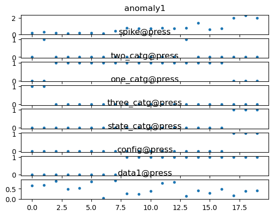

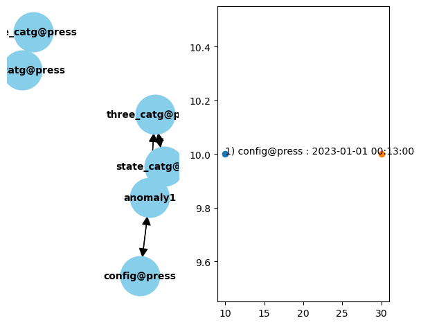

```python
contextTemp.plot()
```

Moreover, we can plot all the context of ContextGeneration (at a more abstract level) using the plot method.

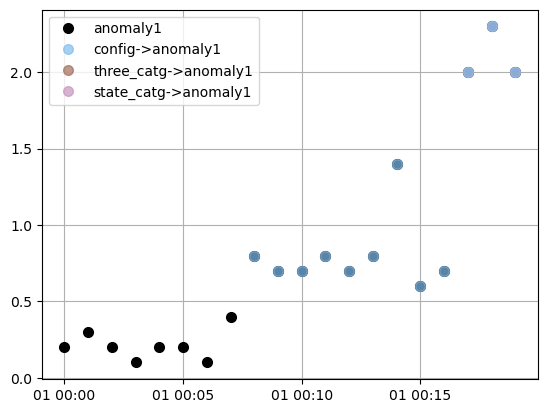

```python
con_gen.plot(context_list,[["","anomaly1",""]])
```

The values on this plot refer to the target value used to build each context sample, and the colors are refered to the relationships that exist in the CR of each context object). In that example, we can see that the anomaly1 series has an increase due to the config event (as seen from the CR)

## Causality Discovery

The user can implement and provide to the Context Generator its own causality discovery method:

To do this simply needs to implement a Python function, that takes as a parameter:

1. A list with names of time series data
2. The time series data in the form of a 2D array
3. The timestamps of the time series data (which can be ignored for now)

Example: PdmContext.utils.causal_discovery_functions.calculatewithPc

```python
import networkx as nx
# pip install castle
from castle.algorithms import PC
def calculatewithPc(names, data,timestamps):
    try:
        pc = PC(variant='parallel')
        pc.learn(data)
    except Exception as e:
        print(e)
        return None

    learned_graph = nx.DiGraph(pc.causal_matrix)
    # Relabel the nodes
    MAPPING = {k: n for k, n in zip(range(len(names)), names)}
    learned_graph = nx.relabel_nodes(learned_graph, MAPPING, copy=True)
    edges=learned_graph.edges
    return edges
```

## Database Connections

The current implementation supports connection with two databases (SQLlite3 and Influxdb) using the PdmContext.utils.dbconnector.SQLiteHandler, and PdmContext.utils.dbconnector.InfluxDBHandler

Using SQLite will create a database in the location of the main file.

Using Influxdb need to start the Influxdb services before starting: (For example in Linux: sudo service influxdb start)

Both databases Connections can be used with the implemented pipeline: PdmContext.Pipelines.ContextAndDatabase

Let's generate the same example as before but this time store it to the Database

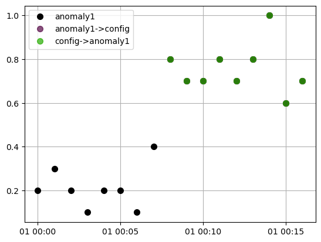

```python
from PdmContext.utils.dbconnector import SQLiteHandler
from PdmContext.Pipelines import ContextAndDatabase


con_gen = ContextGenerator(target="anomaly1", context_horizon="8", Causalityfunct=calculatewithPc, debug=False)
database = SQLiteHandler(db_name="ContextDatabase.db")
contextpipeline = ContextAndDatabase(context_generator_object=con_gen, databaseStore_object=database)

configur = [0, 0, 0, 0, 0, 0, 0, 0, 1, 0, 0, 0, 0, 0, 0, 0, 0]
data1 = [random() for i in range(len(configur))]
start = pd.to_datetime("2023-01-01 00:00:00")
timestamps = [start + pd.Timedelta(minutes=i) for i in range(len(data1))]
anomaly1 = [0.2, 0.3, 0.2, 0.1, 0.2, 0.2, 0.1, 0.4, 0.8, 0.7, 0.7, 0.8, 0.7, 0.8, 1, 0.6, 0.7]

spikes = [0 for i in range(len(data1))]
spikes[1] = 1
spikes[13] = 1

source = "press"
context_list=[]
for d1, an1, t1, sp1, con1 in zip(data1, anomaly1, timestamps, spikes, configur):
    contextpipeline.collect_data(timestamp=t1, source=source, name="data1", value=d1)
    if sp1 == 1:
        contextpipeline.collect_data(timestamp=t1, source=source, name="spike", type="isolated")
    if con1 == 1:
        contextpipeline.collect_data(timestamp=t1, source=source, name="config", type="configuration")
    contextTemp = contextpipeline.collect_data(timestamp=t1, source=source, name="anomaly1", value=an1)
    context_list.append(contextTemp)
contextpipeline.Contexter.plot(context_list)
```

Now we can acces the Context objexcts stored in the Database:

```python
database = SQLiteHandler(db_name="ContextDatabase.db")
traget_name = "anomaly1"
contextlist = database.get_all_context_by_target(traget_name)
print(len(contextlist))
```

```
17
```

We could also plot the contexts using the helper function from PdmContext.utils.showcontext.show_Context_list

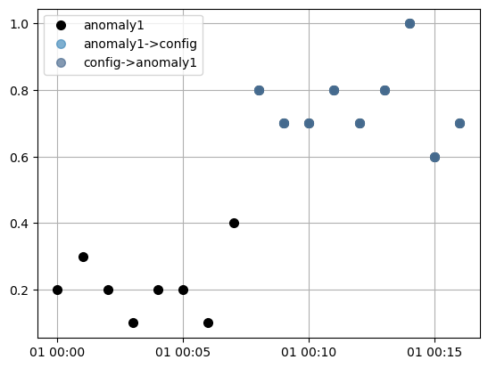

```python
from PdmContext.utils.showcontext import show_context_list
show_context_list(contextlist, target_text=traget_name)
```

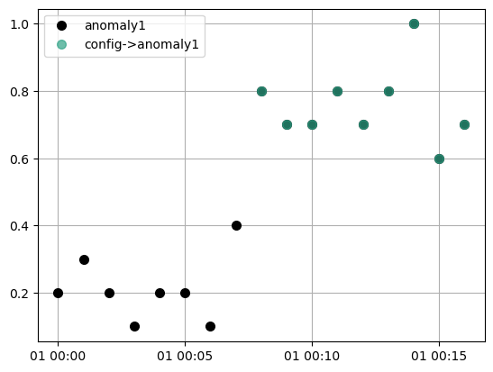

```python
show_context_list(contextlist, target_text=traget_name, filteredges=[["config", "anomaly1", ""]])
```

## Distance Function

To compare two Context objects we need a similarity (or distance measure).

The user can implement its own distance function, which accepts only two parameters (two Context objects)

Below there is an example which uses the distance_cc (which is the SBD distance of between the CD and Jaccard similarity between the CR of the two contexts weighted by a factor a and b=1-a)

In this example we builr our own distance function **my_distance(c1: Context,c2 Context)** by using specific a and b

```python
from PdmContext.utils.distances import distance_cc

def my_distance(c1:Context,c2:Context):

    return distance_cc(c1,c2,a=0)

# JACCARD similarity between the CR components
print(my_distance(contextlist[0],contextlist[-1]))
print(my_distance(contextlist[-2],contextlist[-1]))
```

```
0
1.0
```

## Clustering Context

Using the PdmContext.ContextClustering.DBscanContextStreamClustering we can cluster over Context objects.

Clustering over context object has two main limitations:

1. streaming interface (when we want to cluster the context objects as they arrive from the Context Generator
2. appropriate distance measurement

Regarding 1) an example of a simplified DBscan algorithm for streaming data has been developed in PdmContext.ContextClustering.DBscanContextStreamClustering (we can iteratively feed cluster method using add_sample_to_cluster method)

While for 2) a sample of distance functions exist in PdmContext.utils.distances, and the user can define its own as shown previously

Creating a PdmContext.ContextClustering.DBscanContextStreamClustering object

```
[[0, 1, 2, 3, 4, 5, 6, 7], [8, 9, 10, 11, 12, 13, 14, 15, 16]]
```

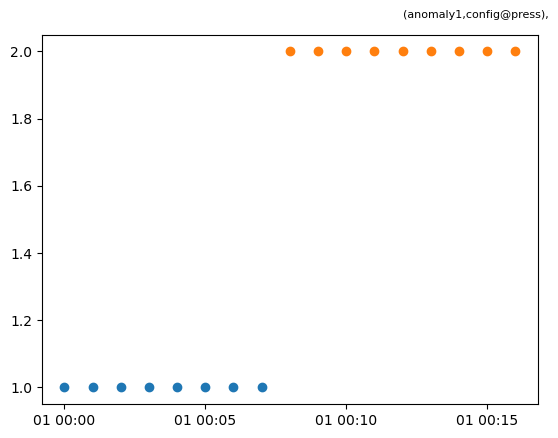

```python
from PdmContext.ContextClustering import DBscanContextStream


# use the distance function from before
clustering=DBscanContextStream(cluster_similarity_limit=0.7,distancefunc=my_distance)

for context_object in contextlist:
    clustering.add_sample_to_cluster(context_object)

print(clustering.clusters_sets)
clustering.plot()
```

The use of the Cluster and ContextGenerator can be also implemented using the Pipeline ContextAndClustering (PdmContext.Pipelines.ContextAndClustering)

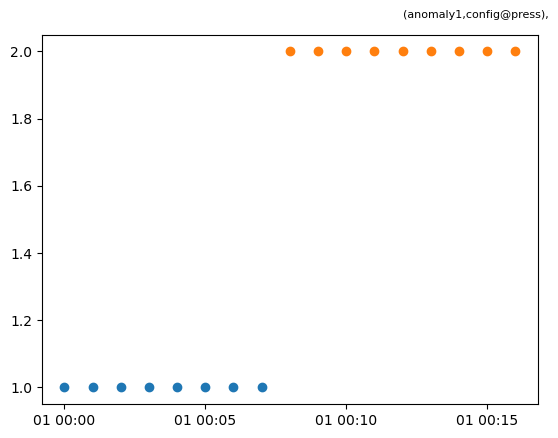

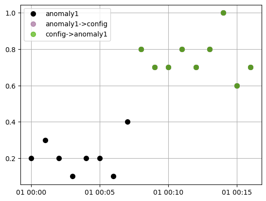

```python
from PdmContext.Pipelines import ContextAndClustering

con_gen_2 = ContextGenerator(target="anomaly1", context_horizon="8 hours", Causalityfunct=calculatewithPc, debug=False)
clustering_2=DBscanContextStream(cluster_similarity_limit=0.7,min_points=2,distancefunc=my_distance)

contextpipeline2 = ContextAndClustering(context_generator_object=con_gen_2,Clustring_object=clustering_2)


source = "press"
context_list=[]
for d1, an1, t1, sp1, con1 in zip(data1, anomaly1, timestamps, spikes, configur):
    contextpipeline2.collect_data(timestamp=t1, source=source, name="data1", value=d1)
    if sp1 == 1:
        contextpipeline2.collect_data(timestamp=t1, source=source, name="spike", type="isolated")
    if con1 == 1:
        contextpipeline2.collect_data(timestamp=t1, source=source, name="config", type="configuration")
    contextTemp = contextpipeline2.collect_data(timestamp=t1, source=source, name="anomaly1", value=an1)
    context_list.append(contextTemp)
contextpipeline2.clustering.plot()
contextpipeline2.Contexter.plot(context_list)
```

## Pipelines

There are three pipeline that wrap the Database Connector, Context Generator, and Clustering (all using the same API of collect_data as Context Generator)

1. PdmContext.Pipelines.ContextAndClustering (wrap Context generator and feed its result to clustering)
2. PdmContext.Pipelines import ContextAndDatabase (wrap Context generator and feed its result to the database)
3. PdmContext.Pipelines import ContextAndClusteringAndDatabase (wrap Context generator and feed its result to database and clustering)

## Simulators

Because Context Generator works in a streaming fashion there are implemented simulators that can be used as helpers for the user (PdmContext.utils.simulate_stream)

### Simulator stream

Example (PdmContext.utils.simulate_stream.simulate_stream):

This simulator needs to pass three (optionally) lists and the target name.

1. Time series data: which contain tuples of with shape ( name: str, timestamps:list, values:list )
2. Event series data: which contain tuples of : (name: str, occurrences :list of Dates, type:str)
3. Categorical event series data: which contain tuples of : (name: str, occurrences :list of Dates, categories: list, type:str)
4. target name

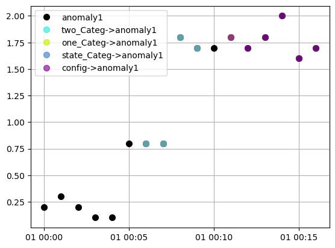

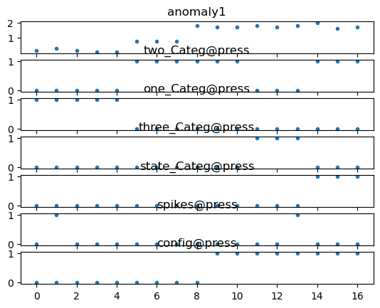

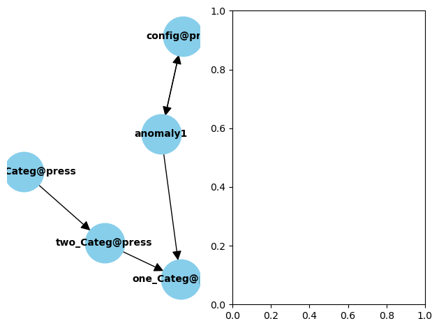

```python
from PdmContext.utils.simulate_stream import simulate_stream
from PdmContext.ContextGeneration import ContextGenerator
import pandas as pd
from random import random

start2 = pd.to_datetime("2023-01-01 00:00:00")
timestamps2 = [start2 + pd.Timedelta(minutes=i) for i in range(17)]

eventconf2=("config",[pd.to_datetime("2023-01-01 00:09:00")],"configuration")
spiketuples2=("spikes",[pd.to_datetime("2023-01-01 00:01:00"),pd.to_datetime("2023-01-01 00:13:00")],"isolated")
categories=("Categ",timestamps2, ["one", "one","one","one","one","two","two","two","two","two","two","three", "three", "three", "two", "two","two"],"categorical")

anomaly1tuples2=("anomaly1", [0.2, 0.3, 0.2, 0.1, 0.1, 0.8, 0.8, 0.8, 1.8, 1.7, 1.7, 1.8, 1.7, 1.8, 2, 1.6, 1.7],timestamps2)

stream=simulate_stream([anomaly1tuples2],[eventconf2,spiketuples2],[categories],"anomaly1")

contextpipeline3 =  ContextGenerator(target="anomaly1", context_horizon="8 hours", Causalityfunct=calculatewithPc)
source="press"

context_list=[]
for record in stream:
    #print(record)
    context_res=contextpipeline3.collect_data(timestamp=record["timestamp"], source=source, name=record["name"], type=record["type"],value=record["value"])
    if context_res is not None:
        context_list.append(context_res)
contextpipeline3.plot(context_list,[["", "anomaly1", ""]])
contextpipeline3.contexts[-1].plot()
```

### Simulator using pandas DataFrame

In the case of an existing dataframe with all data.

Example (PdmContext.utils.simulate_stream.simulate_from_df):

This simulator needs to pass two list

1. A dataframe
2. Which columns represent events and of what type example [("column1","isolated"),("column3","configuration")]
3. Target name (existing in dataframes column)

```
                        data1  configur  anomaly1  spikes
2023-01-01 00:00:00  0.263462         0       0.2       0
2023-01-01 00:01:00  0.827615         0       0.3       1
2023-01-01 00:02:00  0.381941         0       0.2       0
2023-01-01 00:03:00  0.327193         0       0.1       0
2023-01-01 00:04:00  0.837698         0       0.2       0
```

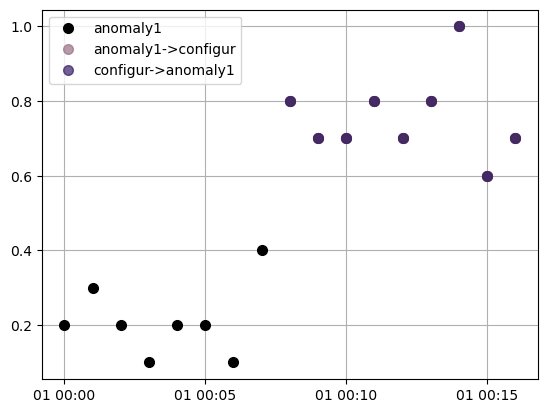

```python
from PdmContext.utils.simulate_stream import simulate_from_df

df = pd.read_csv("dummy_data.csv",index_col=0)
df.index=pd.to_datetime(df.index)
print(df.head())
traget_name="anomaly1"
stream = simulate_from_df(df,[("configur","configuration"),("spikes","isolated")], traget_name)

contextpipeline4 =  ContextGenerator(target="anomaly1", context_horizon="8 hours", Causalityfunct=calculatewithPc)

source = "press"
context_list=[]
for record in stream:
    context_res=contextpipeline4.collect_data(timestamp=record["timestamp"], source=source, name=record["name"], type=record["type"],value=record["value"])
    if context_res is not None:
        context_list.append(context_res)

contextpipeline4.plot(context_list)
```

### Interpretation

Based on the edges in the Contexts CR (generated by Causal Discovery), we can try to interpret the target series behavior.

For example, having the below case of two configuration events and one isolated along with an anomaly score.

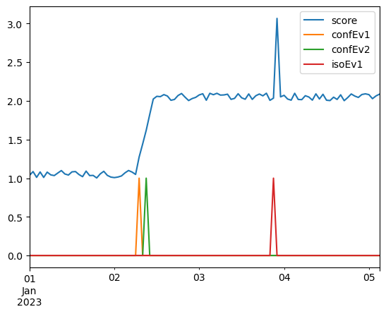

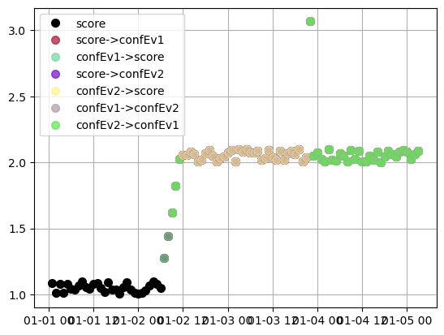

```python
from PdmContext.ContextGeneration import ContextGenerator
from PdmContext.utils.causal_discovery_functions import calculate_with_pc
from PdmContext.utils.simulate_stream import simulate_from_df
from random import random
import matplotlib.pyplot as plt
import pandas as pd

size=100
isoEv1=[0 for i in range(size)]
confevent1=[0 for i in range(size)]
confevent2=[0 for i in range(size)]
noise=random()/10
start = pd.to_datetime("2023-01-01 00:00:00")
timestamps = [start + pd.Timedelta(hours=i) for i in range(size)]
confevent1[31]=1
confevent2[33]=1
isoEv1[69]=1
score=[1+random()/10 for i in range(30)]+ [1+(i/5)+random()/10 for i in range(5)] +[2+random()/10 for i in range(65)]

score[70]+=1
contextgenerator=ContextGenerator(target="score",context_horizon="100",Causalityfunct=calculate_with_pc)


dfdata={
    "score":score,
    "confEv1":confevent1,
    "confEv2":confevent2,
    "isoEv1":isoEv1,
}
df=pd.DataFrame(dfdata,index=timestamps)
df.plot()
plt.show()

stream = simulate_from_df(df,eventTypes=[("isoEv1","isolated"),("confEv1","configuration"),("confEv2","configuration")],target_name="score")
source="press"
listcontexts=[]
for record in stream:
    context_res=contextgenerator.collect_data(timestamp=record["timestamp"], source=source, name=record["name"], type=record["type"],value=record["value"])
    if context_res is not None:
        listcontexts.append(context_res)
contextgenerator.plot(listcontexts)
```

In the two plots we can observe the raw data (upper), and the interpretation (lower). Regarding the interpertation plot in the lower part, due to space limitation we observe only a part of the interpertations.

Looking closer to the time where the increse start and the when a spike occurs, we can take a better understanding of the interpertation.

Below we will plot the CD and CR part of the context. For the CD part the data series will be showed and for CR part, the graph structure of the causality discovery (left) along with interpertation (right) will be depicted.

```
1) confEv1@press : 2023-01-02 12:00:00
```

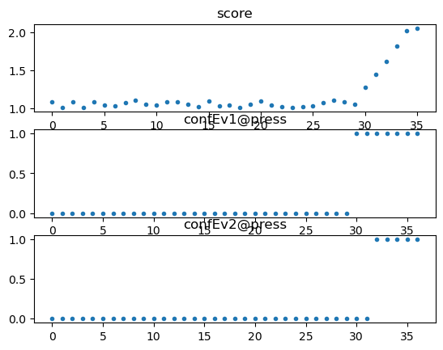

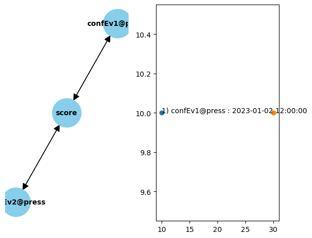

```python
listcontexts[35].plot()
```

Using this timestamp we can conclude better on what may cause increase in the score.

```
1) confEv1@press : 2023-01-02 11:00:00
2) confEv2@press : 2023-01-02 13:00:00
```

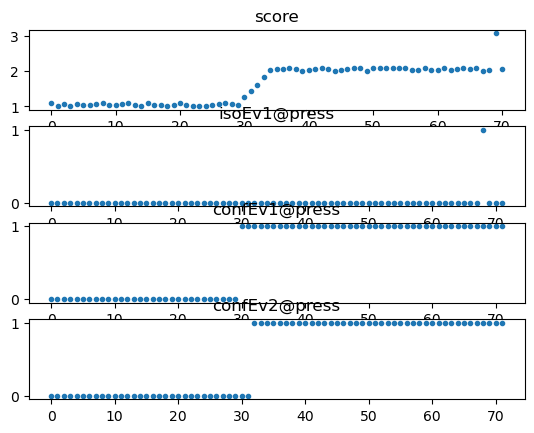

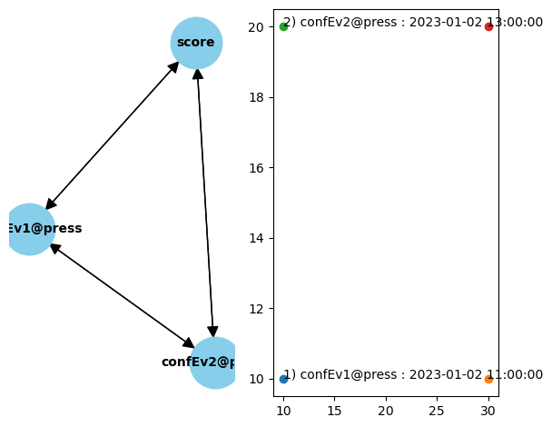

```python
listcontexts[70].plot()
```

## Causality Discovery Efficiency

To calculate context we perform Causality Discovery over the mapped signals. Thus, causality discovery calculated is performed for every new observation of the target signal. To deal with that we implement a moving Causality Discovery version of PC algorithm combined with Fishers z-transformation independence test. Under `utils.MovingPC` we implement the class `RunningCovarianceTimestamps()` which handle the calculation of aggregated signals' statistics on the fly, able to delete and add new data samples. By that way the process of Causality Discovery becomes a lot faster, considering that as new target samples are observed there is little change to data (e.g. a few samples are added and subtracted from the context horizon) This class is leveraged by `utils.MovingPC.MovingPC` and can be used by creating an object and passing the method calculate_with_pc_moving to the context generation class.

```
from PdMContext.ContextGenerator import ContextGenerator
from PdMContext.utils.MovingPC import MovingPC

MPC=MovingPC()

con_gen=ContextGenerator(target="anomaly scores", context_horizon="8 hours",Causality_function=MPC.calculate_with_pc_moving)
```

**Caution**: In order to use this functionality there is on requirement, that the mapping functions produce stable transformations, meaning that the values of already observed timestamps are not changing by the mapping function.

The default mapping (Isolated, Configuration and Univariate) produce stable transformation except for the case of categorical values.